# Are Video Games Getting More Popular Overtime?

### Overall the sports category has the highest number of sales which we can safely assume to be 'Wii Sports'. However, 'Wii Sports' comes in a bundle so that game should not count as much. Plus, the cluster in sports is less dense than compared to Platform, Racing, Role-Playing, Shooter, and Action games. This shows these games are more popular than that of the Sports genre which would make sense. Platform has the Mario franchise, Racing has Forza and Asphault, Role-Playing has Dark Souls and the Witcher, Shooter has Call of Duty and Battlefield, and Action has Street Fighter and Super Smash Bros. All of these games are popular in there own communities; nevertheless, the density of games in the Shooter genre seems to be the highest. In addition to games such as Fortnite, Apex, and Overwatch the Shooter genre has never been so popular.

### Now lets check the residuals of each year with Global_Sales as the response variable. First, we will create another column called 'residuals' and calculate the residual of each data point using the intercept and coefficient of the linear regression from the Global_Sales scatterplot. Next, we will produce a boxplot of the residuals for each year which will show where the data is bunched up and any outliers. This can show us from a different perspective on which years produced more popular video games.

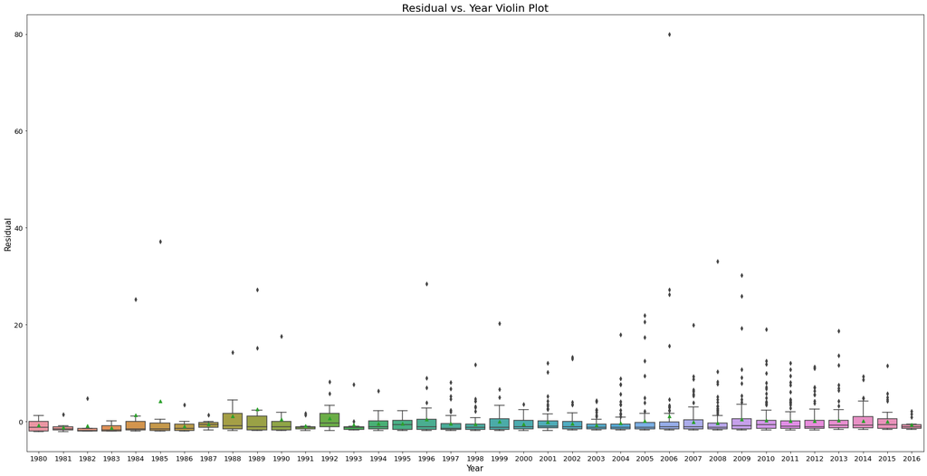

```python
data['residuals'] = data['Global_Sales'] - (Global_int + Global_coef * data['Year'])
a4_dims = (30, 15)
fig, ax = plt.subplots(figsize=a4_dims)
sb.boxplot(x = 'Year', y = 'residuals', data = data, showmeans=True)
plt.xlabel("Year", size = 15)
plt.ylabel("Residual", size = 15)
plt.title("Residual vs. Year Violin Plot", size = 20)
plt.xticks(fontsize=13)
plt.yticks(fontsize=13);
```

### The graph is small but there is one thing that is apparent which is the number of outliers on the graph. There are many more outliers from 2004 and onwards which does indicate that games could have been more popular during that time. This makes a little more sense as technology was developing at a rapid pace, so more people could obtain a gaming station to play video games.

## *Conclusion*

### As you can see we can easily take data from good sources, transform the data to help us with future calculations, plot charts to visualize the data given to us, and use machine learning to help us see trends in the data. But the big question still remains...

### ''Are Video Games Becoming More Popular Overtime?"

### Given the data from above it would seem from the time frame of the 1980's-2016 that games did become slightly more popular. Sure the linear regression for global, NA, and JP decreased overtime, but it was barely a decrease. The linear regression for the other areas increased and the residuals show that quite a few games had good sales towards 2010. Plus, personally this makes sense overall many more games are coming out with better graphics. More and more people are finding enjoyment through these games which boasts numerous genres to a wide audience. There are even more factors such as the time frame of 2017-2020 (which probably would have impacted the results) that were not included in the scope of this project. Will video games ever lose its popularity in the future? I do not know. What I do know is that as of this moment the video game community is slowly growing it will probably not slow down in the near future.